# 회귀분석 기말고사

20180968 박서현

2020 12 15

```r
library(binom)
```

```r
library(ggplot2)
library(PropCIs)
library(data.table)
library(readxl)
library(epitools)
library(DescTools)
library(dplyr)
library(MASS)
library(car)
library(lmtest)
library(faraway)
library(mdscore)
library(xlsx)
library(VGAM)
library(lattice)
library(tseries)
```

# 1.

```r
cigarette=read.table("C:/Users/nabib/Documents/GitHub/Statics/1215/data/Cigarette_Consumption.txt",header=TRUE)
cigarette
```

```
##    State  Age   HS Income Black Female Price Sales
## 1     AL 27.0 41.3   2948  26.2   51.7  42.7  89.8
## 2     AK 22.9 66.7   4644   3.0   45.7  41.8 121.3
## 3     AZ 26.3 58.1   3665   3.0   50.8  38.5 115.2
## 4     AR 29.1 39.9   2878  18.3   51.5  38.8 100.3
## 5     CA 28.1 62.6   4493   7.0   50.8  39.7 123.0
## 6     CO 26.2 63.9   3855   3.0   50.7  31.1 124.8
## 7     CT 29.1 56.0   4917   6.0   51.5  45.5 120.0
## 8     DE 26.8 54.6   4524  14.3   51.3  41.3 155.0
## 9     DC 28.4 55.2   5079  71.1   53.5  32.6 200.4
## 10    FL 32.3 52.6   3738  15.3   51.8  43.8 123.6
## 11    GA 25.9 40.6   3354  25.9   51.4  35.8 109.9
## 12    HI 25.0 61.9   4623   1.0   48.0  36.7  82.1
## 13    ID 26.4 59.5   3290   0.3   50.1  33.6 102.4
## 14    IL 28.6 52.6   4507  12.8   51.5  41.4 124.8
```

[output cut: 37 more lines]

```r
str(cigarette)
```

```
## 'data.frame':    51 obs. of  8 variables:
##  $ State : chr  "AL" "AK" "AZ" "AR" ...
##  $ Age   : num  27 22.9 26.3 29.1 28.1 26.2 29.1 26.8 28.4 32.3 ...
##  $ HS    : num  41.3 66.7 58.1 39.9 62.6 63.9 56 54.6 55.2 52.6 ...
##  $ Income: num  2948 4644 3665 2878 4493 ...
##  $ Black : num  26.2 3 3 18.3 7 3 6 14.3 71.1 15.3 ...
##  $ Female: num  51.7 45.7 50.8 51.5 50.8 50.7 51.5 51.3 53.5 51.8 ...
##  $ Price : num  42.7 41.8 38.5 38.8 39.7 31.1 45.5 41.3 32.6 43.8 ...
##  $ Sales : num  89.8 121.3 115.2 100.3 123 ...
```

## (1)

- 귀무가설: Female 변수는 유의한 설명변수가 아니다.
- 대립가설: Female 변수는 유의한 설명변수이다.

```r
fit = lm(Sales ~ Age + HS + Income + Black + Female + Price, data = cigarette)
summary(fit)
```

```
##
## Call:
## lm(formula = Sales ~ Age + HS + Income + Black + Female + Price,
##     data = cigarette)
##
## Residuals:
##     Min      1Q  Median      3Q     Max
## -48.398 -12.388  -5.367   6.270 133.213
##
## Coefficients:
##              Estimate Std. Error t value Pr(>|t|)
## (Intercept) 103.34485  245.60719   0.421  0.67597
## Age           4.52045    3.21977   1.404  0.16735
## HS           -0.06159    0.81468  -0.076  0.94008
## Income        0.01895    0.01022   1.855  0.07036 .
## Black         0.35754    0.48722   0.734  0.46695
## Female       -1.05286    5.56101  -0.189  0.85071
## Price        -3.25492    1.03141  -3.156  0.00289 **
## ---
## Signif. codes:  0 '***' 0.001 '**' 0.01 '*' 0.05 '.' 0.1 ' ' 1
##
## Residual standard error: 28.17 on 44 degrees of freedom
## Multiple R-squared:  0.3208, Adjusted R-squared:  0.2282
## F-statistic: 3.464 on 6 and 44 DF,  p-value: 0.006857
```

```r
fit_female = lm(Sales ~ Age + HS + Income + Black + Price, data = cigarette)
summary(fit_female)
```

```
##
## Call:
## lm(formula = Sales ~ Age + HS + Income + Black + Price, data = cigarette)
##
## Residuals:
##     Min      1Q  Median      3Q     Max
## -47.089 -11.767  -5.525   5.650 132.873
##
## Coefficients:
##              Estimate Std. Error t value Pr(>|t|)
## (Intercept) 59.463336  80.387585   0.740  0.46332
## Age          4.117758   2.391184   1.722  0.09193 .
## HS          -0.066817   0.805446  -0.083  0.93425
## Income       0.019458   0.009746   1.997  0.05194 .
## Black        0.311472   0.417577   0.746  0.45961
## Price       -3.252022   1.020186  -3.188  0.00261 **
## ---
## Signif. codes:  0 '***' 0.001 '**' 0.01 '*' 0.05 '.' 0.1 ' ' 1
##
## Residual standard error: 27.87 on 45 degrees of freedom
## Multiple R-squared:  0.3203, Adjusted R-squared:  0.2448
## F-statistic: 4.241 on 5 and 45 DF,  p-value: 0.003039
```

```r
anova(fit, fit_female)
```

```
## Analysis of Variance Table
##
## Model 1: Sales ~ Age + HS + Income + Black + Female + Price
## Model 2: Sales ~ Age + HS + Income + Black + Price
##   Res.Df   RSS Df Sum of Sq      F Pr(>F)
## 1     44 34926
## 2     45 34954 -1   -28.453 0.0358 0.8507
```

p-value가 0.05보다 크다 -> 귀무가설 기각 못 한다.  
즉 female 변수는 유의미한 설명변수가 아니다.

## (2)

- 귀무가설: Female 변수와 HS는 유의한 설명변수가 아니다. (동시에 사용했을 때)
- 대립가설: Female 변수와 HS는 유의한 설명변수이다.(동시에 사용했을 때)

```r
fit = lm(Sales ~ Age + HS + Income + Black + Female + Price, data = cigarette)
summary(fit)
```

```
##
## Call:
## lm(formula = Sales ~ Age + HS + Income + Black + Female + Price,
##     data = cigarette)
##
## Residuals:
##     Min      1Q  Median      3Q     Max
## -48.398 -12.388  -5.367   6.270 133.213
##
## Coefficients:
##              Estimate Std. Error t value Pr(>|t|)
## (Intercept) 103.34485  245.60719   0.421  0.67597
## Age           4.52045    3.21977   1.404  0.16735
## HS           -0.06159    0.81468  -0.076  0.94008
## Income        0.01895    0.01022   1.855  0.07036 .
## Black         0.35754    0.48722   0.734  0.46695
## Female       -1.05286    5.56101  -0.189  0.85071
## Price        -3.25492    1.03141  -3.156  0.00289 **
## ---
## Signif. codes:  0 '***' 0.001 '**' 0.01 '*' 0.05 '.' 0.1 ' ' 1
##
## Residual standard error: 28.17 on 44 degrees of freedom
## Multiple R-squared:  0.3208, Adjusted R-squared:  0.2282
## F-statistic: 3.464 on 6 and 44 DF,  p-value: 0.006857
```

```r
fit_fh = lm(Sales ~ Age + Income + Black + Price, data = cigarette)
summary(fit_fh)
```

```
##
## Call:
## lm(formula = Sales ~ Age + Income + Black + Price, data = cigarette)
##
## Residuals:
##     Min      1Q  Median      3Q     Max
## -46.784 -11.810  -5.380   5.758 132.789
##
## Coefficients:
##              Estimate Std. Error t value Pr(>|t|)
## (Intercept) 55.329580  62.395293   0.887   0.3798
## Age          4.191538   2.195535   1.909   0.0625 .
## Income       0.018892   0.006882   2.745   0.0086 **
## Black        0.334162   0.312098   1.071   0.2899
## Price       -3.239941   0.998778  -3.244   0.0022 **
## ---
## Signif. codes:  0 '***' 0.001 '**' 0.01 '*' 0.05 '.' 0.1 ' ' 1
##
## Residual standard error: 27.57 on 46 degrees of freedom
## Multiple R-squared:  0.3202, Adjusted R-squared:  0.2611
## F-statistic: 5.416 on 4 and 46 DF,  p-value: 0.001168
```

```r
anova(fit, fit_fh)
```

```
## Analysis of Variance Table
##
## Model 1: Sales ~ Age + HS + Income + Black + Female + Price
## Model 2: Sales ~ Age + Income + Black + Price
##   Res.Df   RSS Df Sum of Sq      F Pr(>F)
## 1     44 34926
## 2     46 34960 -2   -33.799 0.0213 0.9789
```

p-value가 0.05보다 크다 -> 귀무가설 기각 못 한다.  
즉 female 변수와 HS는 유의미한 설명변수가 아니다. (동시에 사용)

## (3)

```r
fit_i <- lm(Sales ~ Income, data=cigarette)
summary(fit_i)
```

```
##
## Call:
## lm(formula = Sales ~ Income, data = cigarette)
##
## Residuals:
##     Min      1Q  Median      3Q     Max
## -54.550 -15.772  -6.517   4.491 144.628
##
## Coefficients:
##              Estimate Std. Error t value Pr(>|t|)
## (Intercept) 55.362454  27.743082   1.996   0.0516 .
## Income       0.017583   0.007283   2.414   0.0195 *
## ---
## Signif. codes:  0 '***' 0.001 '**' 0.01 '*' 0.05 '.' 0.1 ' ' 1
##
## Residual standard error: 30.63 on 49 degrees of freedom
## Multiple R-squared:  0.1063, Adjusted R-squared:  0.08808
## F-statistic: 5.829 on 1 and 49 DF,  p-value: 0.01954
```

```r
coefficients(fit_i)
```

```
## (Intercept)      Income
## 55.36245411  0.01758339
```

```r
confint(fit_i, level=0.95)
```

```
##                    2.5 %       97.5 %
## (Intercept) -0.389356463 111.11426469
## Income       0.002948423   0.03221836
```

## (4)

```r
fit = lm(Sales ~ Age + HS + Income + Black + Female + Price, data = cigarette)
summary(fit)
```

```
##
## Call:
## lm(formula = Sales ~ Age + HS + Income + Black + Female + Price,
##     data = cigarette)
##
## Residuals:
##     Min      1Q  Median      3Q     Max
## -48.398 -12.388  -5.367   6.270 133.213
##
## Coefficients:
##              Estimate Std. Error t value Pr(>|t|)
## (Intercept) 103.34485  245.60719   0.421  0.67597
## Age           4.52045    3.21977   1.404  0.16735
## HS           -0.06159    0.81468  -0.076  0.94008
## Income        0.01895    0.01022   1.855  0.07036 .
## Black         0.35754    0.48722   0.734  0.46695
## Female       -1.05286    5.56101  -0.189  0.85071
## Price        -3.25492    1.03141  -3.156  0.00289 **
## ---
## Signif. codes:  0 '***' 0.001 '**' 0.01 '*' 0.05 '.' 0.1 ' ' 1
##
## Residual standard error: 28.17 on 44 degrees of freedom
## Multiple R-squared:  0.3208, Adjusted R-squared:  0.2282
## F-statistic: 3.464 on 6 and 44 DF,  p-value: 0.006857
```

```r
fit_income = lm(Sales ~ Age + Black + Female + Price, data = cigarette)
summary(fit_income)
```

```
##
## Call:
## lm(formula = Sales ~ Age + Black + Female + Price, data = cigarette)
##
## Residuals:
##     Min      1Q  Median      3Q     Max
## -36.120 -17.134  -4.437   8.510 135.560
##
## Coefficients:
##             Estimate Std. Error t value Pr(>|t|)
## (Intercept) 306.2388   237.0018   1.292  0.20276
## Age           7.4349     2.9710   2.502  0.01595 *
## Black         0.6095     0.4011   1.520  0.13545
## Female       -5.6133     5.4738  -1.025  0.31050
## Price        -2.8627     1.0534  -2.718  0.00924 **
## ---
## Signif. codes:  0 '***' 0.001 '**' 0.01 '*' 0.05 '.' 0.1 ' ' 1
##
## Residual standard error: 29.41 on 46 degrees of freedom
## Multiple R-squared:  0.2265, Adjusted R-squared:  0.1592
## F-statistic: 3.368 on 4 and 46 DF,  p-value: 0.01689
```

```r
anova(fit, fit_income)
```

```
## Analysis of Variance Table
##
## Model 1: Sales ~ Age + HS + Income + Black + Female + Price
## Model 2: Sales ~ Age + Black + Female + Price
##   Res.Df   RSS Df Sum of Sq      F  Pr(>F)
## 1     44 34926
## 2     46 39777 -2   -4851.3 3.0559 0.05719 .
## ---
## Signif. codes:  0 '***' 0.001 '**' 0.01 '*' 0.05 '.' 0.1 ' ' 1
```

income을 포함시켰을 때의 p-value는 0.006857이고, income을 포함하지 않았을 경우의 p-value는 0.01689이다.

## (5)

```r
fit_income2 = lm(Sales ~ Income, data = cigarette)
summary(fit_income2)
```

```
##
## Call:
## lm(formula = Sales ~ Income, data = cigarette)
##
## Residuals:
##     Min      1Q  Median      3Q     Max
## -54.550 -15.772  -6.517   4.491 144.628
##
## Coefficients:
##              Estimate Std. Error t value Pr(>|t|)
## (Intercept) 55.362454  27.743082   1.996   0.0516 .
## Income       0.017583   0.007283   2.414   0.0195 *
## ---
## Signif. codes:  0 '***' 0.001 '**' 0.01 '*' 0.05 '.' 0.1 ' ' 1
##
## Residual standard error: 30.63 on 49 degrees of freedom
## Multiple R-squared:  0.1063, Adjusted R-squared:  0.08808
## F-statistic: 5.829 on 1 and 49 DF,  p-value: 0.01954
```

```r
anova(fit, fit_income2)
```

```
## Analysis of Variance Table
##
## Model 1: Sales ~ Age + HS + Income + Black + Female + Price
## Model 2: Sales ~ Income
##   Res.Df   RSS Df Sum of Sq      F  Pr(>F)
## 1     44 34926
## 2     49 45958 -5    -11032 2.7796 0.02883 *
## ---
## Signif. codes:  0 '***' 0.001 '**' 0.01 '*' 0.05 '.' 0.1 ' ' 1
```

4번 결과와 같지 않다. anova 결과가 같지 않기 때문이다.

## (6)

```r
fit_6 = lm(Sales ~ Price + Age + Income, data=cigarette)
summary(fit_6)
```

```
##
## Call:
## lm(formula = Sales ~ Price + Age + Income, data = cigarette)
##
## Residuals:
##     Min      1Q  Median      3Q     Max
## -50.430 -13.853  -4.962   6.691 128.947
##
## Coefficients:
##              Estimate Std. Error t value Pr(>|t|)
## (Intercept) 64.248227  61.933008   1.037  0.30487
## Price       -3.399234   0.989172  -3.436  0.00124 **
## Age          4.155909   2.198699   1.890  0.06491 .
## Income       0.019281   0.006883   2.801  0.00737 **
## ---
## Signif. codes:  0 '***' 0.001 '**' 0.01 '*' 0.05 '.' 0.1 ' ' 1
##
## Residual standard error: 27.61 on 47 degrees of freedom
## Multiple R-squared:  0.3032, Adjusted R-squared:  0.2588
## F-statistic: 6.818 on 3 and 47 DF,  p-value: 0.0006565
```

```r
anova(fit, fit_6)
```

```
## Analysis of Variance Table
##
## Model 1: Sales ~ Age + HS + Income + Black + Female + Price
## Model 2: Sales ~ Price + Age + Income
##   Res.Df   RSS Df Sum of Sq      F Pr(>F)
## 1     44 34926
## 2     47 35831 -3   -905.05 0.3801 0.7678
```

## (7)

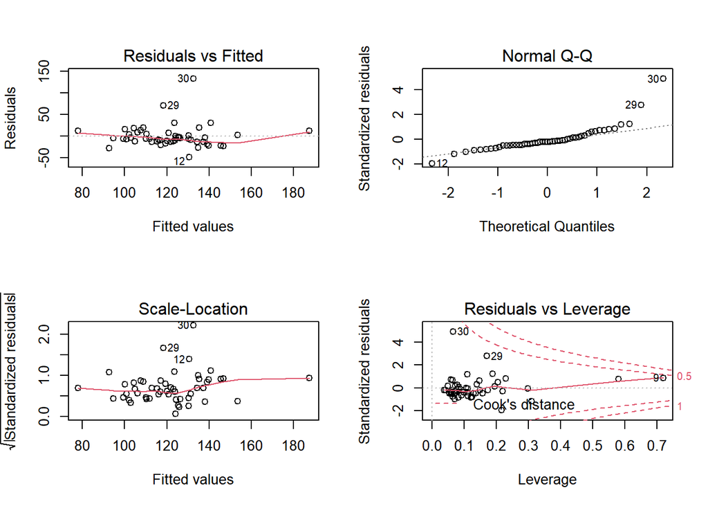

```r
op = par(mfrow=c(2, 2))
plot(fit)
```

```r
par(op)
```

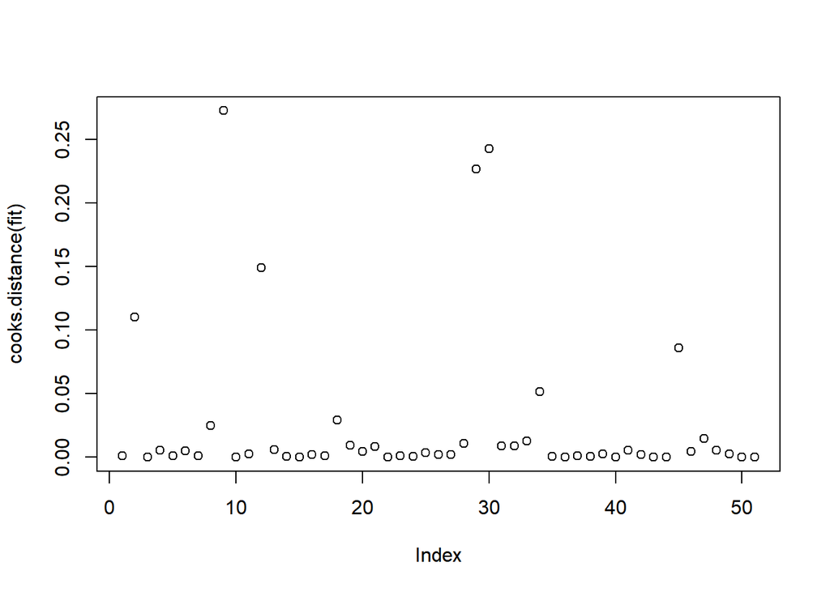

```r
plot(cooks.distance(fit))
```

```r
outlierTest(fit)
```

```
##    rstudent unadjusted p-value Bonferroni p
## 30 7.165222         7.4236e-09   3.7861e-07
```

모여있는 점과 달리 간간이 위에 튀어나온 데이터들이 보인다.

이 데이터가 이상치이다.

## (8)

```r
vif(fit)
```

```
##      Age       HS   Income    Black   Female    Price
## 2.300617 2.676465 2.325164 2.392152 2.406417 1.142181
```

VIF가 모두 충분히 크지 않는 것을 볼 수 있다.

## (9)

```r
step <- stepAIC(fit, direction="both")
```

```
## Start:  AIC=346.99
## Sales ~ Age + HS + Income + Black + Female + Price
##
##          Df Sum of Sq   RSS    AIC
## - HS      1       4.5 34931 344.99
## - Female  1      28.5 34954 345.03
## - Black   1     427.4 35353 345.61
## <none>                34926 346.99
## - Age     1    1564.6 36491 347.22
## - Income  1    2730.2 37656 348.83
## - Price   1    7905.3 42831 355.39
##
## Step:  AIC=344.99
## Sales ~ Age + Income + Black + Female + Price
##
##          Df Sum of Sq   RSS    AIC
## - Female  1      29.3 34960 343.04
## - Black   1     729.3 35660 344.05
## <none>                34931 344.99
## - Age     1    1777.4 36708 345.52
## + HS      1       4.5 34926 346.99
## - Income  1    4846.8 39777 349.62
## - Price   1    8013.4 42944 353.53
##
## Step:  AIC=343.04
## Sales ~ Age + Income + Black + Price
##
##          Df Sum of Sq   RSS    AIC
## - Black   1     871.3 35831 342.29
## <none>                34960 343.04
## - Age     1    2770.0 37730 344.93
## + Female  1      29.3 34931 344.99
## + HS      1       5.3 34954 345.03
## - Income  1    5726.9 40687 348.77
## - Price   1    7997.4 42957 351.54
##
## Step:  AIC=342.29
## Sales ~ Age + Income + Price
##
##          Df Sum of Sq   RSS    AIC
## <none>                35831 342.29
## + Black   1     871.3 34960 343.04
## + HS      1     444.4 35387 343.66
## - Age     1    2723.7 38555 344.03
## + Female  1     171.3 35660 344.05
## - Income  1    5981.8 41813 348.17
## - Price   1    9002.8 44834 351.72
```

```r
step$anova
```

```
## Stepwise Model Path
## Analysis of Deviance Table
##
## Initial Model:
## Sales ~ Age + HS + Income + Black + Female + Price
##
## Final Model:
## Sales ~ Age + Income + Price
##
##
##       Step Df   Deviance Resid. Df Resid. Dev      AIC
## 1                               44   34925.97 346.9872
## 2     - HS  1   4.536091        45   34930.50 344.9938
## 3 - Female  1  29.262468        46   34959.77 343.0365
## 4  - Black  1 871.250868        47   35831.02 342.2919
```

HS, Female, Black 순으로 중요하지 않다는 점을 알 수 있다.

## (10)

```r
fit_test <- lm(Sales ~ Age + Income + Price, data=cigarette)
summary(fit_test)
```

```
##
## Call:
## lm(formula = Sales ~ Age + Income + Price, data = cigarette)
##
## Residuals:
##     Min      1Q  Median      3Q     Max
## -50.430 -13.853  -4.962   6.691 128.947
##
## Coefficients:
##              Estimate Std. Error t value Pr(>|t|)
## (Intercept) 64.248227  61.933008   1.037  0.30487
## Age          4.155909   2.198699   1.890  0.06491 .
## Income       0.019281   0.006883   2.801  0.00737 **
## Price       -3.399234   0.989172  -3.436  0.00124 **
## ---
## Signif. codes:  0 '***' 0.001 '**' 0.01 '*' 0.05 '.' 0.1 ' ' 1
##
## Residual standard error: 27.61 on 47 degrees of freedom
## Multiple R-squared:  0.3032, Adjusted R-squared:  0.2588
## F-statistic: 6.818 on 3 and 47 DF,  p-value: 0.0006565
```

```r
anova(fit, fit_test)
```

```
## Analysis of Variance Table
##
## Model 1: Sales ~ Age + HS + Income + Black + Female + Price
## Model 2: Sales ~ Age + Income + Price
##   Res.Df   RSS Df Sum of Sq      F Pr(>F)
## 1     44 34926
## 2     47 35831 -3   -905.05 0.3801 0.7678
```

9번에서 추천받은 변수 3개(HS, Female, Black)를 제거했을 경우가 가장 결과가 잘 나왔다.

# 2.

```r
two=read.table("C:/Users/nabib/Documents/GitHub/Statics/1215/data/기말문제2번데이터.txt",header=TRUE)
two
```

```
##      Y  X1  X2  X3 X4 X5  X6
## 1  443  49  79  76  8 15 205
## 2  290  27  70  31  6  6 129
## 3  676 115  92 130  0  9 339
## 4  536  92  62  92  5  8 247
## 5  481  67  42  94 16  3 202
## 6  296  31  54  34 14 11 119
## 7  453 105  60  47  5 10 212
## 8  617 114  85  84 17 20 285
## 9  514  98  72  71 12 -1 242
## 10 400  15  59  99 15 11 174
## 11 473  62  62  81  9  1 207
## 12 157  25  11   7  9  9  45
## 13 440  45  65  84 19 13 195
## 14 480  92  75  63  9 20 232
```

[output cut: 26 more lines]

## (1)

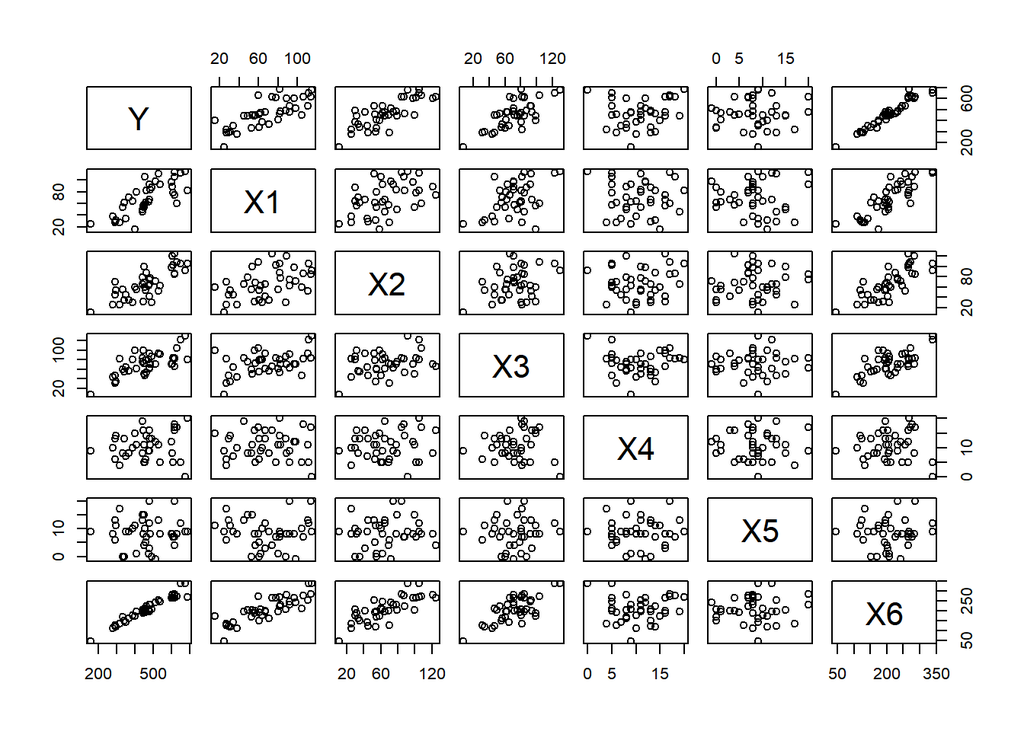

```r
plot(two)
```

```r
result <- lm(Y ~ X1 + X2 + X3 + X4 + X5 + X6, data=two)
summary(result)
```

```
##
## Call:
## lm(formula = Y ~ X1 + X2 + X3 + X4 + X5 + X6, data = two)
##
## Residuals:
##     Min      1Q  Median      3Q     Max
## -54.267 -15.427   2.524  13.633  71.438
##
## Coefficients:
##             Estimate Std. Error t value Pr(>|t|)
## (Intercept)  35.1772    22.0755   1.593  0.12058
## X1            2.8547     5.3372   0.535  0.59632
## X2            3.2753     5.3330   0.614  0.54332
## X3            3.1863     5.2887   0.602  0.55098
## X4            3.1878     0.9918   3.214  0.00292 **
## X5           -0.6677     0.8934  -0.747  0.46014
## X6           -1.1658     5.3217  -0.219  0.82794
## ---
## Signif. codes:  0 '***' 0.001 '**' 0.01 '*' 0.05 '.' 0.1 ' ' 1
##
## Residual standard error: 28.5 on 33 degrees of freedom
## Multiple R-squared:  0.9559, Adjusted R-squared:  0.9479
## F-statistic: 119.3 on 6 and 33 DF,  p-value: < 2.2e-16
```

```r
vif(result)
```

```
##          X1          X2          X3          X4          X5          X6
## 1062.167136 1103.595644  764.394462    1.036287    1.023312 5310.504807
```

VIF 값이 지나치게 높은 것을 확인할 수 있다.

회귀모형의 가정 중 하나인 독립성을 위배하고 있으니, 다중공선성을 제거해주어야 한다.

## (2)

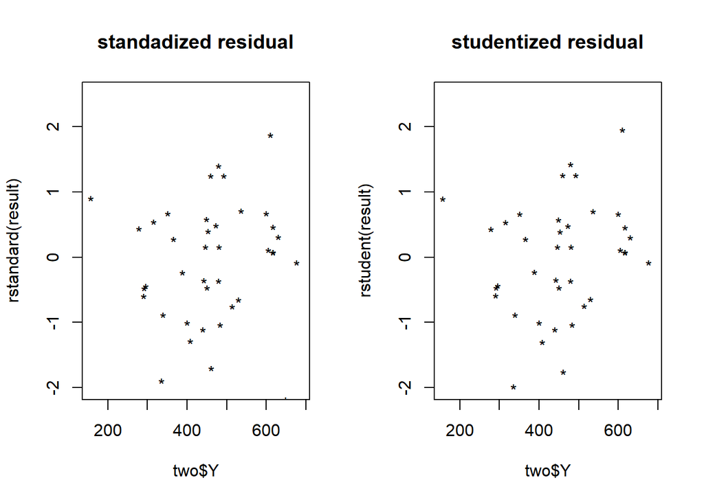

```r
par(mfrow=c(1, 2))
plot(two$Y, rstandard(result), ylim=c(-2, 2.5),  pch="*", main="standadized residual")
plot(two$Y, rstudent(result), ylim=c(-2, 2.5),  pch="*", main="studentized residual")
```

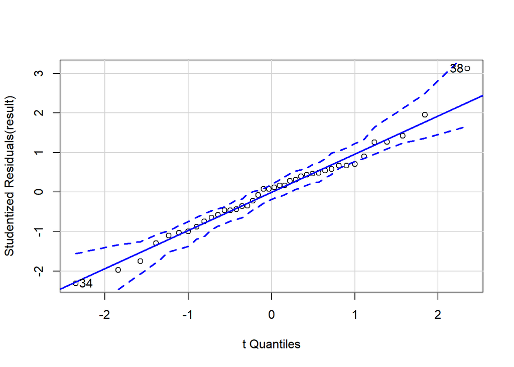

```
## [1] 34 38
```

```r
qqPlot(result)
```

## (3)

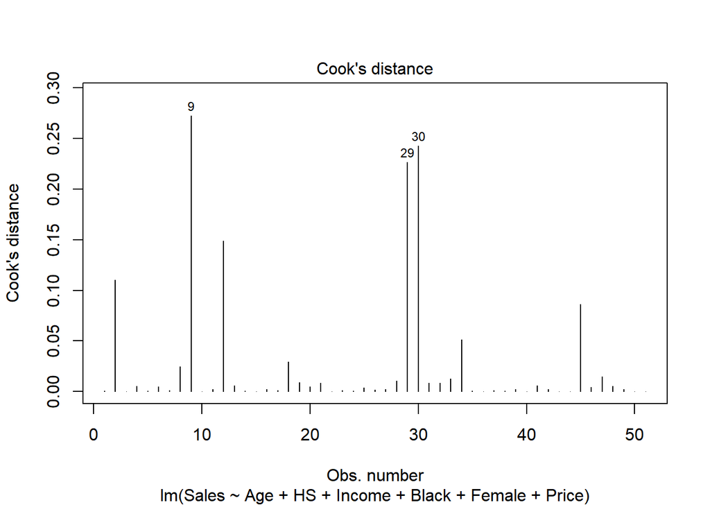

```r
cutoff <- 6/((nrow(two$Y) - length(result$coefficients) -2))
plot(fit, which=4, cook.levels=cutoff)
```

```r
outlierTest(result)
```

```
## No Studentized residuals with Bonferroni p < 0.05
## Largest |rstudent|:
##    rstudent unadjusted p-value Bonferroni p
## 38 3.119525          0.0038192      0.15277
```

## (4)

```r
vif(result)
```

```
##          X1          X2          X3          X4          X5          X6
## 1062.167136 1103.595644  764.394462    1.036287    1.023312 5310.504807
```

VIF 값이 지나치게 높은 것을 확인할 수 있다.

다중공선성이 발생할 수 있다.

## (5)

```r
step <- stepAIC(result, direction="both")
```

```
## Start:  AIC=274.31
## Y ~ X1 + X2 + X3 + X4 + X5 + X6
##
##        Df Sum of Sq   RSS    AIC
## - X6    1      39.0 26852 272.37
## - X1    1     232.5 27045 272.66
## - X3    1     294.9 27108 272.75
## - X2    1     306.5 27119 272.76
## - X5    1     453.8 27267 272.98
## <none>              26813 274.31
## - X4    1    8393.8 35207 283.20
##
## Step:  AIC=272.37
## Y ~ X1 + X2 + X3 + X4 + X5
##
##        Df Sum of Sq    RSS    AIC
## - X5    1       441  27293 271.02
## <none>               26852 272.37
## + X6    1        39  26813 274.31
## - X4    1      8626  35478 281.51
## - X1    1     57280  84132 316.05
## - X3    1     71412  98264 322.26
## - X2    1    104243 131095 333.79
##
## Step:  AIC=271.02
## Y ~ X1 + X2 + X3 + X4
##
##        Df Sum of Sq    RSS    AIC
## <none>               27293 271.02
## + X5    1       441  26852 272.37
## + X6    1        26  27267 272.98
## - X4    1      8727  36020 280.12
## - X1    1     58811  86104 314.98
## - X3    1     71034  98327 320.29
## - X2    1    104172 131465 331.90
```

```r
step$anova
```

```
## Stepwise Model Path
## Analysis of Deviance Table
##
## Initial Model:
## Y ~ X1 + X2 + X3 + X4 + X5 + X6
##
## Final Model:
## Y ~ X1 + X2 + X3 + X4
##
##
##   Step Df  Deviance Resid. Df Resid. Dev      AIC
## 1                          33   26812.94 274.3104
## 2 - X6  1  38.99477        34   26851.94 272.3686
## 3 - X5  1 441.25106        35   27293.19 271.0205
```

X6, X5 순으로 유의성이 적은 것을 알 수 있다.

## (6)

```r
result_test <- lm(Y ~ X1 + X2 + X3 + X4, data=two)
summary(result_test)
```

```
##
## Call:
## lm(formula = Y ~ X1 + X2 + X3 + X4, data = two)
##
## Residuals:
##    Min     1Q Median     3Q    Max
## -55.05 -17.03   2.83  17.08  72.40
##
## Coefficients:
##             Estimate Std. Error t value Pr(>|t|)
## (Intercept)  28.3469    18.9141   1.499  0.14291
## X1            1.7006     0.1958   8.684 2.97e-10 ***
## X2            2.0907     0.1809  11.558 1.68e-13 ***
## X3            2.0209     0.2117   9.544 2.83e-11 ***
## X4            3.2295     0.9654   3.345  0.00197 **
## ---
## Signif. codes:  0 '***' 0.001 '**' 0.01 '*' 0.05 '.' 0.1 ' ' 1
##
## Residual standard error: 27.92 on 35 degrees of freedom
## Multiple R-squared:  0.9551, Adjusted R-squared:   0.95
## F-statistic: 186.3 on 4 and 35 DF,  p-value: < 2.2e-16
```

```r
anova(result, result_test)
```

```
## Analysis of Variance Table
##
## Model 1: Y ~ X1 + X2 + X3 + X4 + X5 + X6
## Model 2: Y ~ X1 + X2 + X3 + X4
##   Res.Df   RSS Df Sum of Sq      F Pr(>F)
## 1     33 26813
## 2     35 27293 -2   -480.25 0.2955 0.7461
```

# 3.

```r
salary=read.table("C:/Users/nabib/Documents/GitHub/Statics/1215/data/Salary_survey.txt",header=TRUE)
salary
```

```
##        S  X E M
## 1  13876  1 1 1
## 2  11608  1 3 0
## 3  18701  1 3 1
## 4  11283  1 2 0
## 5  11767  1 3 0
## 6  20872  2 2 1
## 7  11772  2 2 0
## 8  10535  2 1 0
## 9  12195  2 3 0
## 10 12313  3 2 0
## 11 14975  3 1 1
## 12 21371  3 2 1
## 13 19800  3 3 1
## 14 11417  4 1 0
```

[output cut: 32 more lines]

## (1)

```r
fit3_1 <- lm(S ~ E + X, data=salary)
summary(fit3_1)
```

```
##
## Call:
## lm(formula = S ~ E + X, data = salary)
##
## Residuals:
##    Min     1Q Median     3Q    Max
##  -4662  -2667  -1682   2479   6634
##
## Coefficients:
##             Estimate Std. Error t value Pr(>|t|)
## (Intercept)   8279.9     1814.6   4.563 4.18e-05 ***
## E             2418.4      706.9   3.421  0.00138 **
## X              560.8      105.8   5.299 3.78e-06 ***
## ---
## Signif. codes:  0 '***' 0.001 '**' 0.01 '*' 0.05 '.' 0.1 ' ' 1
##
## Residual standard error: 3604 on 43 degrees of freedom
## Multiple R-squared:  0.4422, Adjusted R-squared:  0.4163
## F-statistic: 17.05 on 2 and 43 DF,  p-value: 3.538e-06
```

```r
fit3_2 <- lm(S ~ M + X, data=salary)
summary(fit3_2)
```

```
##
## Call:
## lm(formula = S ~ M + X, data = salary)
##
## Residuals:
##     Min      1Q  Median      3Q     Max
## -4168.2  -896.1   477.7   856.0  2462.4
##
## Coefficients:
##             Estimate Std. Error t value Pr(>|t|)
## (Intercept) 10210.36     526.00   19.41  < 2e-16 ***
## M            7145.02     527.32   13.55  < 2e-16 ***
## X             527.11      51.11   10.31 3.35e-13 ***
## ---
## Signif. codes:  0 '***' 0.001 '**' 0.01 '*' 0.05 '.' 0.1 ' ' 1
##
## Residual standard error: 1771 on 43 degrees of freedom
## Multiple R-squared:  0.8653, Adjusted R-squared:  0.8591
## F-statistic: 138.2 on 2 and 43 DF,  p-value: < 2.2e-16
```

## (2)

- 귀무가설: E는 유의하지 않다.
- 대립가설: E는 유의하다.

```r
fit3 <- lm(S ~ E + M + X, data=salary)
summary(fit3)
```

```
##
## Call:
## lm(formula = S ~ E + M + X, data = salary)
##
## Residuals:
##     Min      1Q  Median      3Q     Max
## -2387.1  -657.6  -116.6   482.4  2922.7
##
## Coefficients:
##             Estimate Std. Error t value Pr(>|t|)
## (Intercept)  6963.48     665.69  10.460 2.88e-13 ***
## E            1578.75     262.32   6.018 3.74e-07 ***
## M            6688.13     398.28  16.793  < 2e-16 ***
## X             570.09      38.56  14.785  < 2e-16 ***
## ---
## Signif. codes:  0 '***' 0.001 '**' 0.01 '*' 0.05 '.' 0.1 ' ' 1
##
## Residual standard error: 1313 on 42 degrees of freedom
## Multiple R-squared:  0.9277, Adjusted R-squared:  0.9225
## F-statistic: 179.6 on 3 and 42 DF,  p-value: < 2.2e-16
```

```r
fit3_E <- lm(S ~  M + X, data=salary)
summary(fit3_E)
```

```
##
## Call:
## lm(formula = S ~ M + X, data = salary)
##
## Residuals:
##     Min      1Q  Median      3Q     Max
## -4168.2  -896.1   477.7   856.0  2462.4
##
## Coefficients:
##             Estimate Std. Error t value Pr(>|t|)
## (Intercept) 10210.36     526.00   19.41  < 2e-16 ***
## M            7145.02     527.32   13.55  < 2e-16 ***
## X             527.11      51.11   10.31 3.35e-13 ***
## ---
## Signif. codes:  0 '***' 0.001 '**' 0.01 '*' 0.05 '.' 0.1 ' ' 1
##
## Residual standard error: 1771 on 43 degrees of freedom
## Multiple R-squared:  0.8653, Adjusted R-squared:  0.8591
## F-statistic: 138.2 on 2 and 43 DF,  p-value: < 2.2e-16
```

```r
anova(fit3, fit3_E)
```

```
## Analysis of Variance Table
##
## Model 1: S ~ E + M + X
## Model 2: S ~ M + X
##   Res.Df       RSS Df Sum of Sq      F    Pr(>F)
## 1     42  72383410
## 2     43 134806963 -1 -62423553 36.221 3.737e-07 ***
## ---
## Signif. codes:  0 '***' 0.001 '**' 0.01 '*' 0.05 '.' 0.1 ' ' 1
```

## (3)

```r
l <- lm(S ~ E + X, data=salary)
summary(l)
```

```
##
## Call:
## lm(formula = S ~ E + X, data = salary)
##
## Residuals:
##    Min     1Q Median     3Q    Max
##  -4662  -2667  -1682   2479   6634
##
## Coefficients:
##             Estimate Std. Error t value Pr(>|t|)
## (Intercept)   8279.9     1814.6   4.563 4.18e-05 ***
## E             2418.4      706.9   3.421  0.00138 **
## X              560.8      105.8   5.299 3.78e-06 ***
## ---
## Signif. codes:  0 '***' 0.001 '**' 0.01 '*' 0.05 '.' 0.1 ' ' 1
##
## Residual standard error: 3604 on 43 degrees of freedom
## Multiple R-squared:  0.4422, Adjusted R-squared:  0.4163
## F-statistic: 17.05 on 2 and 43 DF,  p-value: 3.538e-06
```

```r
grid <- seq(1,5, by=0.5)
seed1 <- l$coefficients[[1]] + l$coefficients[[2]] + l$coefficients[[3]]*grid
seed0 <- l$coefficients[[1]] + l$coefficients[[3]]*grid
```

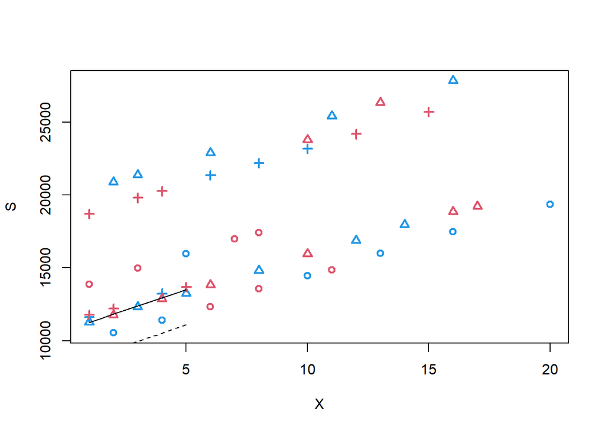

```r
with(plot(S ~ X, pch=E, lwd=2, col=c(2, 4)), data = salary)
legend(2.7, 11, c("E=1", "E=2"), pch=c(2, 0))
lines(grid, seed1, lty=1)
lines(grid, seed0, lty=2)
```

## (4)

```r
vif(fit3)
```

```
##        E        M        X
## 1.077190 1.040455 1.038267
```